# R Markdown

RAdelaide 2025

Author

Affiliation

Dr Stevie Pederson

Black Ochre Data Labs  
The Kids Research Institute Australia

Published

July 10, 2025

# R Markdown

## Writing Reports Using `rmarkdown`

- `rmarkdown` is a cohesive way to
  - Load & wrangle data
  - Analyse data, including figures & tables
  - Publish everything in a complete report/analysis
- The package `knitr` is the engine behind this
  - Replaced the `Sweave` package about 8-10 years ago

Extends the `markdown` language **to incorporate R code**

## Writing Reports Using `rmarkdown`

- Everything is one document
  - Our analysis code embedded alongside our explanatory text
- The entire analysis is performed in a fresh R Environment
  - Avoids issues with saving/re-saving Workspaces
- Enforces code that *runs sequentially*

# Starting With Markdown

## A Brief Primer on Markdown

- Markdown is a simple and elegant way to create formatted HTML
  - Text is entered as plain text
  - Formatting usually doesn’t appear on screen (but **can**)
  - The parsing to HTML often occurs using `pandoc`
- Often used for Project README files etc.
- *Not R-specific* but is heavily-used across data-science
1. Go to the File drop-down menu in RStudio
2. New File -> Markdown File
3. Save As `README.md`

## Editing Markdown

- Section Headers are denoted by one or more `#` symbols
  - `#` is the highest level, `##` is next highest etc.
- Italic text is set by enclosing text between a single asterisk (`*`) or underscore (`_`)
- Bold text is set by using *two asterisks* (`**`) or *two underscores* (`__`)

## Editing Markdown

- Dot-point Lists are started by prefixing each line with `-`
  - Next level indents are formed by adding 2 or 4 spaces before the next `-`
- Numeric Lists are formed by starting a line with `1.`
  - Subsequent lines don’t need to be numbered in order

## Editing Markdown

Let’s quickly edit our file so there’s something informative

Enter this on the top line

`# RAdelaide 2025`

Two lines down add this

`## Day 1`

Leave another blank line then add

`1. Introduction to R and R Studio`  
`2. Importing Data`  
`3. Data Exploration`  
`4. Data Visualisation`

## Editing Markdown

Underneath the list enter:

`**All material**` can be found at [the couse homepage](http://blackochrelabs.au/RAdelaide25/)

- Here we’ve set the first two words to appear in bold font
- The section in the square brackets will appear as text with a hyperlink to the site in the round brackets
- Click the `Preview Button` and an HTML document appears
- Note that README.html has also been produced
  - Sites like github/gitlab render this automatically
  - Obsidian also renders interactively

# R Markdown

## Writing Reports Using `rmarkdown`

- This course was prepared using the next generation known as quarto
- Extends RMarkdown across multiple languages
- People have written entire PhD theses using Rmarkdown

We can output our analysis directly as:

- HTML
- MS Word Documents
- PDF Documents (If you have $\LaTeX$ installed)
- Slidy, `ioslides` or PowerPoint presentations
- Complete Books (using `bookdown`)

We never need to use MS Word, Excel or PowerPoint again!

## Writing Reports Using `rmarkdown`

- The file suffix is `.Rmd`
- Include both markdown + *embedded `R` code.*
- Create all of our figures & tables directly from the data
- Discussions, data, experimental and analytic descriptions
- Mathematical/Statistical equations
- Nicely Formatted Results
- Any other information: citations, hyperlinks etc.

## Creating an *R* Markdown document

Let’s create our first `rmarkdown` document

1. Go to the `File` drop-down menu in RStudio
2. New File -> R Markdown…

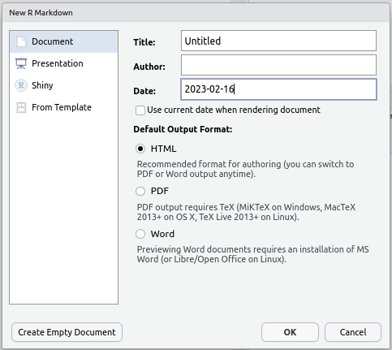

## Creating an *R* Markdown document

1. Change the Title to: My First Report
2. Change the Author to *your preferred name*
3. Leave everything else as it is & hit OK
4. Save the file as `RMarkdownTutorial.Rmd`

## Compiling The Report

- The default format is an `html_document` & we can change this later.
- Generate the default document by clicking `Knit`

## Compiling The Report

The Viewer Pane will appear with the compiled report (probably)

- Note the hyperlink to the RMarkdown website & the bold typeface for the word **Knit**
- The *R* code and the results are printed for `summary(cars)`
- The plot of `temperature` Vs. `pressure` has been embedded
- The code for the plot was hidden using `echo = FALSE`

## Compiling The Report

- We could also export this as an MS Word document by clicking the small ‘down’ arrow next to the word Knit.
- By default, this will be Read-Only, but can be helpful for sharing with collaborators.
- Saving as a `.PDF` requires $\LaTeX$
  - Beyond the scope of today

## Looking At The File

A *header section* is enclosed between the `---` lines at the top

- **Nothing can be placed before this!**
- Uses YAML (**Y**AML **A**in’t **M**arkup **L**anguage)
- Editing is beyond the scope of this course
- Can set custom `.css` files, load LaTeX packages, set parameters etc.

## Looking At The File

- Leaving out the `{r}` will just return formatted code

Lines 8 to 10 are a code `chunk`

- Chunks always begin with ```{r}
- Chunks always end with ```
- Executed `R` code goes between these two delineation marks
- Chunk names are optional and directly follow the letter `r`
  - Chunks can also be other languages (`bash`, `python` etc.)
  - Here the `r` tells RMarkdown the chunk is an `R` chunk
  - If using other languages `quarto` may be best